# FLUXNET data application

2025-08-05

# FLUXNET data

- Variables quick start guide: https://fluxnet.org/data/fluxnet2015-dataset/variables-quick-start-guide/
- Data variables: https://fluxnet.org/data/aboutdata/data-variables/
- Full set data product: https://fluxnet.org/data/fluxnet2015-dataset/fullset-data-product/

# How to save figures using R?

We do not include any codes for saving figures in this tutorial. If you wish to save figures locally, you can use functions like `ggsave()` (for ggplot objects) or base R functions such as `png()` or `pdf()`. Here are some examples:

```r
## ggsave
# ggsave("my_figure.png", plot = p, width = 8, height = 6, dpi = 300)

## base R function
# png("my_plot.png", width = 800, height = 600, res = 150)
# plot(x, y)
# dev.off()
```

# Read data from local drive

```r
# local working directory
data_dir = ("G:/My Drive/FLUX-LSM workshop/US-Syv/AMF_US-Syv_FLUXNET_SUBSET_2001-2023_4-6/"); setwd(data_dir)

# read YY data
{
  filename = "AMF_US-Syv_FLUXNET_SUBSET_YY_2001-2023_4-6.csv"
  setwd(data_dir); df.YY = fread(filename)
  df.YY$year = as.numeric(df.YY$TIMESTAMP)
  df.YY <- df.YY %>%
    mutate(across(everything(), ~na_if(. , -9999)))
}

# read MM data
{
  df.MM = fread(paste0("AMF_US-Syv_FLUXNET_SUBSET_MM_2001-2023_4-6.csv"))
  # FLUXNET data uses "-9999" as placeholder for missing data. Replace -9999 with NA across all columns
  df.MM <- df.MM %>%
    mutate(across(everything(), ~na_if(. , -9999)))

  # Timestamp column of flux data is formatted as YYYYMM. We need to change it to a readable timestamp format.
  df.MM$TIMESTAMP <- ym(as.character(df.MM$TIMESTAMP))

  # Create columns of year
  df.MM <- df.MM %>%
    mutate(year = year(TIMESTAMP), month = month(TIMESTAMP))
}

# read DD data
{
  df.DD = fread(paste0("AMF_US-Syv_FLUXNET_SUBSET_DD_2001-2023_4-6.csv"))
  # FLUXNET data uses "-9999" as placeholder for missing data. Replace -9999 with NA across all columns
  df.DD <- df.DD %>%
    mutate(across(everything(), ~na_if(. , -9999)))

  # Timestamp column of flux data is formatted as YYYYMMDD. We need to change it to a readable timestamp format.
  df.DD$TIMESTAMP <- ymd(as.character(df.DD$TIMESTAMP))

  # Create columns of year and month
  df.DD <- df.DD %>%
    mutate(year = year(TIMESTAMP), month = month(TIMESTAMP))
}

# read HH data
{
  setwd(data_dir); df.HH = fread(paste0("AMF_US-Syv_FLUXNET_SUBSET_HH_2001-2023_4-6.csv"))
  # FLUXNET data uses "-9999" as placeholder for missing data. Replace -9999 with NA across all columns
  df.HH <- df.HH %>%
    mutate(across(everything(), ~na_if(. , -9999)))

  # Timestamp column of flux data is formatted as YYYYMMDDHHMM. We need to change it to a readable timestamp format.
  df.HH$TIMESTAMP_END <- ymd_hm(as.character(df.HH$TIMESTAMP_END))

  # Create columns of year and month
  df.HH <- df.HH %>%
    mutate(year = year(TIMESTAMP_END), month = month(TIMESTAMP_END))
}
```

# Read data on google drive (experimenting)

```r
# if it does not work, comment the codes and download data the read from your local drive manually
library(googledrive)

# Download YY data
{
  file_url <- "https://drive.google.com/file/d/1NMFK0IzCgUInzbdx9xauOjv11Ipv18fL/view?usp=sharing"
  file_id <- googledrive::as_id(file_url)
  temp_file <- tempfile(fileext = ".csv") # Download the file to a temp location
  drive_download(file = file_id, path = temp_file, overwrite = TRUE)
  df.YY <- fread(temp_file)
  df.YY$year = as.numeric(df.YY$TIMESTAMP)
  df.YY <- df.YY %>%
    mutate(across(everything(), ~na_if(. , -9999)))
}
# Download MM data
{

  file_url <- "https://drive.google.com/file/d/1Ycqd7S4RatQNXPmP3fBOrW48QINVmpvi/view?usp=sharing"
  file_id <- googledrive::as_id(file_url)
  temp_file <- tempfile(fileext = ".csv") # Download the file to a temp location
  drive_download(file = file_id, path = temp_file, overwrite = TRUE)
  df.MM <- fread(temp_file)
  df.MM <- df.MM %>%
  mutate(across(everything(), ~na_if(. , -9999)))

  # Timestamp column of flux data is formatted as YYYYMM. We need to change it to a readable timestamp format.
  df.MM$TIMESTAMP <- ym(as.character(df.MM$TIMESTAMP))
  df.MM <- df.MM %>% # Create columns of year
    mutate(year = year(TIMESTAMP), month = month(TIMESTAMP))
}

# Download DD data
{
  file_url <- "https://drive.google.com/file/d/1kGu2JTe5afS_6ly9p3xgVFtTVtpmc__4/view?usp=sharing"
  file_id <- googledrive::as_id(file_url)
  temp_file <- tempfile(fileext = ".csv") # Download the file to a temp location
  drive_download(file = file_id, path = temp_file, overwrite = TRUE)
  df.DD <- fread(temp_file)
    # FLUXNET data uses "-9999" as placeholder for missing data. Replace -9999 with NA across all columns
  df.DD <- df.DD %>%
    mutate(across(everything(), ~na_if(. , -9999)))

  # Timestamp column of flux data is formatted as YYYYMMDD. We need to change it to a readable timestamp format.
  df.DD$TIMESTAMP <- ymd(as.character(df.DD$TIMESTAMP))

  # Create columns of year and month
  df.DD <- df.DD %>%
    mutate(year = year(TIMESTAMP), month = month(TIMESTAMP))
}


# Download HH data
{
  file_url <- "https://drive.google.com/file/d/1oIu4WQxpl49qraD-8_9TfpEwniq3WizE/view?usp=sharing"
  file_id <- googledrive::as_id(file_url)
  temp_file <- tempfile(fileext = ".csv") # Download the file to a temp location
  drive_download(file = file_id, path = temp_file, overwrite = TRUE)
  df.HH <- fread(temp_file)
  df.HH <- df.HH %>%
  mutate(across(everything(), ~na_if(. , -9999)))

  # Timestamp column of flux data is formatted as YYYYMMDDHHMM. We need to change it to a readable timestamp format.
  df.HH$TIMESTAMP_END <- ymd_hm(as.character(df.HH$TIMESTAMP_END))

  # Create columns of year and month
  df.HH <- df.HH %>%
    mutate(year = year(TIMESTAMP_END), month = month(TIMESTAMP_END))
}
```

# Required task

## Task 1: annual sums of NEE

- Variables expressing random uncertainty are identified by the suffix _RANDUNC. One of two methods are used to estimate random uncertainty, applied hierarchically;
- NEE-RANDUNC Method 1 (direct standard deviation method);
- NEE-RANDUNC Method 2 (median standard deviation method) - For more details, please check out Pastorello et al. 2020 NEE_VUT_REF:
- NEE_VUT_REF, using Variable Ustar Threshold (VUT) for each year, reference selected on the basis of the model efficiency (MEF). The MEF analysis is repeated for each time aggregation.

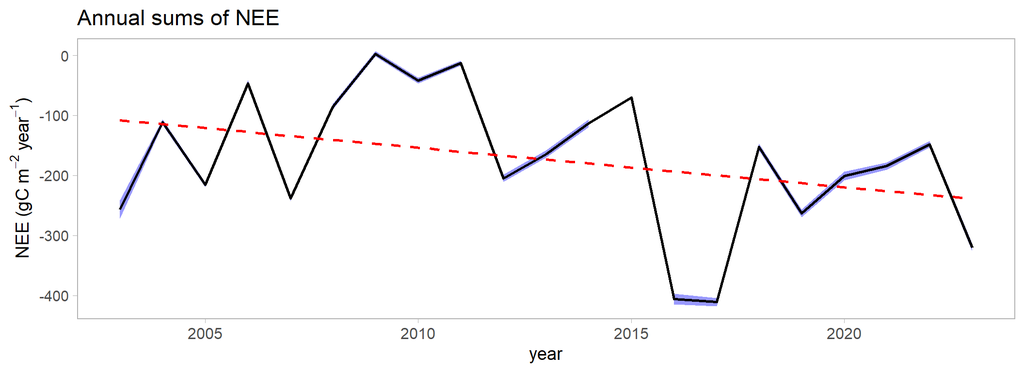

```r
# create upper and lower bounds
# NEE_VUT_REF_RANDUNC
df.YY$NEE_upper <- df.YY$NEE_VUT_REF + df.YY$NEE_VUT_REF_RANDUNC
df.YY$NEE_lower <- df.YY$NEE_VUT_REF - df.YY$NEE_VUT_REF_RANDUNC
ylab = expression("NEE" ~ "(" * gC ~ m^{-2} ~ year^{-1} * ")")

# plot annual sums of NEE across years
ggplot(df.YY, aes(x = year)) +
  geom_ribbon(aes(ymin = NEE_lower, ymax = NEE_upper), fill = "blue", alpha = 0.4) + # random uncertainty
  geom_line(aes(y = NEE_VUT_REF), color = "black", size = 1) +
  geom_smooth(aes(y = NEE_VUT_REF), method = "lm", color = "red", se = FALSE, linetype = "dashed") + # Trend line
  ylab(ylab) +
  ggtitle("Annual sums of NEE") + my_theme
```

```r
# The Mann-Kendall trend test is used to assess whether there is a significant monotonic trend (either increasing or decreasing) in a time series.
MannKendall(df.YY$NEE_VUT_REF) # When P < 0.05, you can reject the null hypothesis ("no trend").
```

```
## tau = -0.181, 2-sided pvalue =0.26387
```

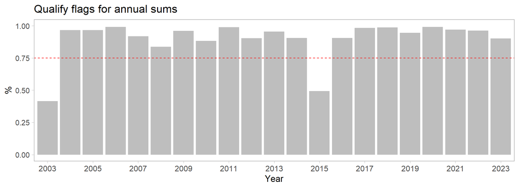

```r
# plot qualify flags of NEE
ggplot(df.YY, aes(x = as.factor(year), y = NEE_VUT_REF_QC)) +
  geom_bar(stat = "identity", fill = "grey") +
  geom_hline(yintercept = 0.75, linetype = "dashed", color = "red") +
  labs(x = "Year", y = "%",
       title = "Qualify flags for annual sums") +
  ylim(0, 1) +
  scale_x_discrete(breaks = df.YY$year[seq(1, nrow(df.YY), by = 2)]) +
  my_theme
```

Where to go from here:

- Interpret the figure and include it in your group presentation.
- Plot annual sums of LE and H (value + uncertainty).
- Explore the qualify flags for annual sums of LE and H.

## Task 2: monthly average NEE, GPP, RECO

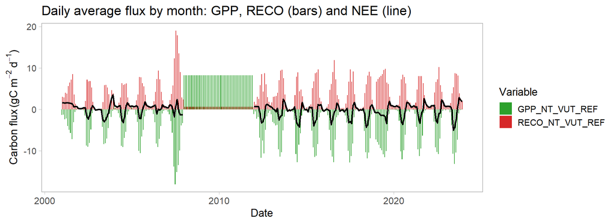

```r
ylab = expression("Carbon flux" ~ "(" * gC ~ m^{-2} ~ d^{-1} * ")") # monthly average

# Create date label for graphing
df.MM <- df.MM %>%
  mutate(
    date = as.Date(paste(year, month, "01", sep = "-"))
  )

# Pivot data for easier plotting
df.MM_long <- df.MM %>%
  mutate(GPP_NT_VUT_REF = -GPP_NT_VUT_REF) %>%  # make GPP negative
  select(date, year, GPP_NT_VUT_REF, RECO_NT_VUT_REF, NEE_VUT_REF) %>%
  pivot_longer(cols = c(GPP_NT_VUT_REF, RECO_NT_VUT_REF), names_to = "variable", values_to = "value")

# Create the plot
ggplot() +
  # Bar plots for GPP and RECO
  geom_col(data = df.MM_long, aes(x = date, y = value, fill = variable), position = "dodge") +
  # Line for NEE
  geom_line(data = df.MM, aes(x = date, y = NEE_VUT_REF), color = "black", size = 1) +
  scale_fill_manual(values = c("GPP_NT_VUT_REF" = "#2ca02c", "RECO_NT_VUT_REF" = "#d62728")) +
  labs(x = "Date", y = ylab, fill = "Variable",
       title = "Daily average flux by month: GPP, RECO (bars) and NEE (line)") + my_theme
```

Where to go from here:

- Interpret the figures and include them in your group presentation;
- You can also create your own figures, e.g. monthly anomalies, or diurnal patterns;

## Task 3: qualify flags for half-hourly data

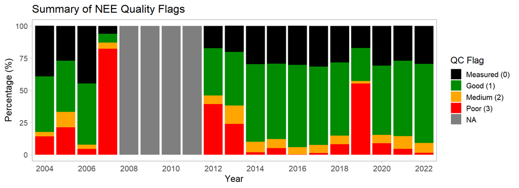

```r
df.HH <- df.HH %>% # using half-hourly data
  mutate(
    year = year(TIMESTAMP_END),
    DOY = yday(TIMESTAMP_END) +
      (hour(TIMESTAMP_END) + minute(TIMESTAMP_END)/60 + second(TIMESTAMP_END)/3600) / 24,
    qc_label = factor(
      NEE_VUT_REF_QC,
      levels = c(0, 1, 2, 3),
      labels = c("Measured (0)", "Good (1)", "Medium (2)", "Poor (3)")
    )
  )

# calculate the percentage of each flag
qc_summary <- df.HH %>%
  group_by(year, qc_label) %>%
  summarise(count = n(), .groups = "drop") %>%
  group_by(year) %>%
  mutate(
    total = sum(count),
    percent = round(100 * count / total, 1),
    label = paste0(qc_label, ": ", percent, "%")
  )


# barplot of qc_summary (% for different qualify flags) by year
qc_summary %>%
  filter(year >= 2004, year <= 2022) %>%
  ggplot(aes(x = factor(year), y = percent, fill = qc_label)) +
  geom_bar(stat = "identity") +
  scale_fill_manual(
    name = "QC Flag",
    values = c(
      "Measured (0)" = "black",
      "Good (1)" = "green4",
      "Medium (2)" = "orange",
      "Poor (3)" = "red"
    )
  ) +
  scale_x_discrete(breaks = as.character(seq(2004, 2022, by = 2))) +
  labs(
    title = "Summary of NEE Quality Flags",
    x = "Year", y = "Percentage (%)"
  ) + my_theme
```

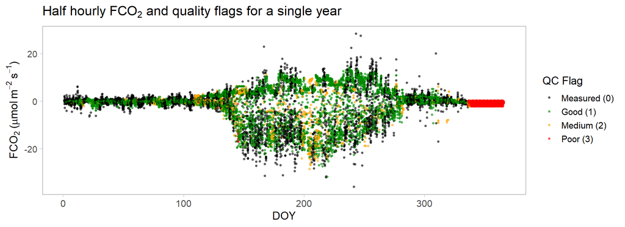

```r
qc_labels <- qc_summary %>%
  group_by(year) %>%
  summarise(
    qc_text = paste(label, collapse = "\n"),
    .groups = "drop"
  )

data_with_labels <- df.HH %>%
  left_join(qc_labels, by = "year")

# looking into data for one year: plot NEE with QC flags
data_with_labels %>%
  filter(year == 2018) %>% # filter data for one year
  ggplot(aes(x = DOY, y = NEE_VUT_REF, color = qc_label)) +
  geom_point(alpha = 0.6, size = 1) +
  scale_color_manual(
    name = "QC Flag",
    values = c("Measured (0)" = "black",
               "Good (1)" = "green4",
               "Medium (2)" = "orange",
               "Poor (3)" = "red")
  ) +
  labs(
    title = expression("Half hourly FCO"[2]*" and quality flags for a single year"),
    x = "DOY", y = expression(FCO[2] ~ "(" * mu * "mol" ~ m^{-2} ~ s^{-1} * ")")
  ) + my_theme
```

Where to go from here:

- Interpret the figures and include them in your group presentation;

## Task 4: monthly average meteorological variables

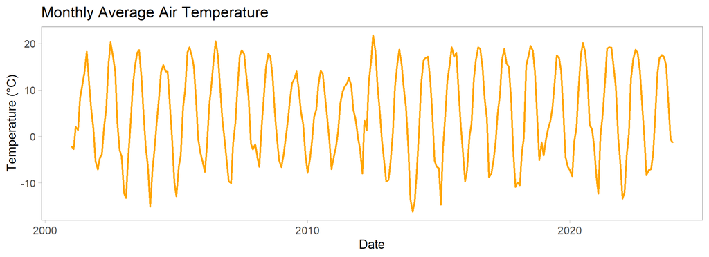

```r
# Air Temperature
ggplot() +
  geom_line(data = df.MM, aes(x = date, y = TA_F), color = "orange", size = 1) +
  labs(x = "Date", y = "Temperature (\u00B0C)", fill = "Variable",
       title = "Monthly Average Air Temperature")+
  my_theme
```

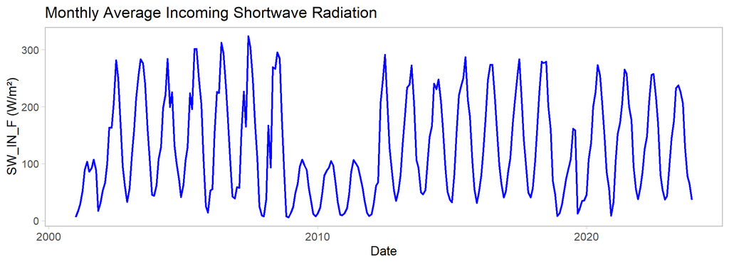

```r
# Incoming shortwave radiation
ggplot() +
  geom_line(data = df.MM, aes(x = date, y = SW_IN_F), color = "blue", size = 1) +
  labs(x = "Date", y = "SW_IN_F (W/m²)", fill = "Variable",
       title = "Monthly Average Incoming Shortwave Radiation") +
  my_theme
```

Please check: - Is the data consistent? Are there any noticeable outliers? - what other important meteorological variables should be checked?

# Bonus task

## Task 1: Light use efficiency

The light response curve describes how **Net Ecosystem Exchange (NEE)** responds to incoming light (PPFD – photosynthetic photon flux density). It is a key tool for quantifying ecosystem carbon uptake characteristics.

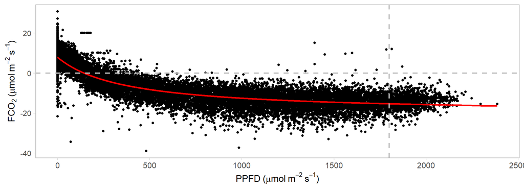

```r
data_filtered = df.HH[df.HH$month == 7, ] # specify the period you want like to focus on
data_filtered$PPFD = data_filtered$PPFD_IN
data_filtered$NEE = data_filtered$NEE_VUT_REF

# Function to calculate light response curve for NEE based on the Michaelis-Menten equation
light_response_NEE <- function(PPFD, Amax, alpha, Rd) {
  -((Amax * PPFD) / (alpha + PPFD) - Rd)
} # > The negative sign reflects the convention that **NEE is negative during net CO₂ uptake** (photosynthesis > respiration).

# Fit the model using non-linear least squares
fit_NEE <- nls(NEE ~ light_response_NEE(PPFD, Amax, alpha, Rd),
               data = data_filtered,
               start = list(Amax = max(-data_filtered$NEE, na.rm = TRUE),
                            alpha = 200, Rd = 2))

# Extract model parameter estimates
params <- coef(fit_NEE)
Amax_est <- round(params["Amax"], 2)
alpha_est <- round(params["alpha"], 2)
Rd_est <- round(params["Rd"], 2)

# Compute NEE at 2000 μmol m⁻² s⁻¹ light intensity
A2000 = Amax_est * 2000/(alpha_est + 2000)

# Generate predicted values from the fitted model
data_filtered$NEE_pred <- predict(fit_NEE, newdata = data_filtered)
ggplot(data_filtered, aes(x = PPFD, y = NEE))  +
  geom_point() +
  geom_line(aes(y = NEE_pred), color = "red", size = 1.2) +
  geom_hline(yintercept = 0, linetype = "dashed", color = "grey", size = 1) +
  geom_vline(xintercept = 1800, linetype = "dashed", color = "grey", size = 1) +
  labs(x = expression(PPFD ~ "(" * mu * "mol" ~ m^{-2} ~ s^{-1} * ")"),
       y = expression(FCO[2] ~ "(" * mu * "mol" ~ m^{-2} ~ s^{-1} * ")")) +
  my_theme
```

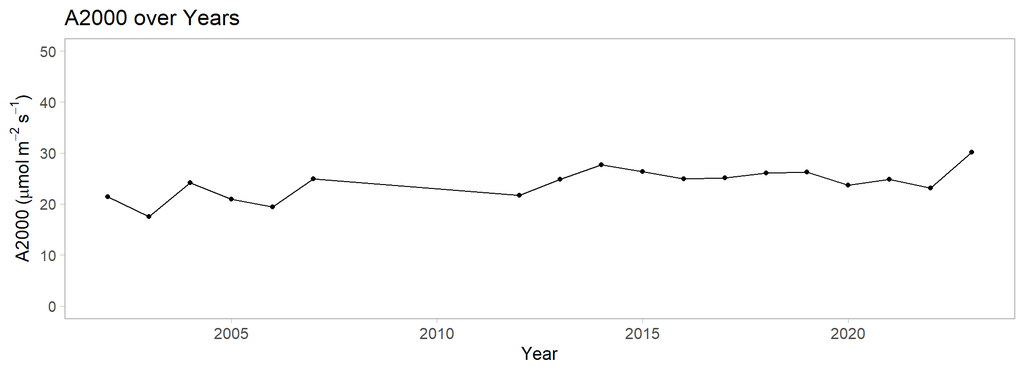

```r
# Function to compute A2000
fit_light_response_NEE <- function(data) {
  # Skip if not enough data
  if (nrow(data) < 10 || all(is.na(data$NEE))) return(NULL)

  # Michaelis-Menten light response model
  light_response_NEE <- function(PPFD, Amax, alpha, Rd) {
    -((Amax * PPFD) / (alpha + PPFD) - Rd)
  }

  # Try fitting the model, catch failures
  fit_result <- tryCatch({
    nls(NEE ~ light_response_NEE(PPFD, Amax, alpha, Rd),
        data = data,
        start = list(
          Amax = max(-data$NEE, na.rm = TRUE),  # guess based on data
          alpha = 200,
          Rd = 2
        ),
        control = nls.control(maxiter = 100, warnOnly = TRUE)
    )
  }, error = function(e) {
    message("Model failed for one year: ", e$message)
    return(NULL)
  })

  # If fitting was successful, extract A2000
  if (!is.null(fit_result)) {
    params <- coef(fit_result)
    Amax <- params["Amax"]
    alpha <- params["alpha"]
    A2000 <- Amax * 2000 / (alpha + 2000)
    return(data.frame(Amax = Amax, alpha = alpha, Rd = params["Rd"], A2000 = A2000))
  } else {
    return(NULL)
  }
}

# compute A2000 for each year
data_by_year <- split(data_filtered, data_filtered$year)
results_by_year <- lapply(data_by_year, fit_light_response_NEE)
names(results_by_year) <- names(data_by_year)
results_df <- bind_rows(results_by_year, .id = "Year")

ggplot(results_df, aes(x = as.numeric(Year), y = A2000)) +
  geom_line() +
  geom_point() +
  labs(title = "A2000 over Years", x = "Year",
       y = expression(A2000 ~ "(" * mu * "mol" ~ m^{-2} ~ s^{-1} * ")")) +
  ylim(0,50) + my_theme
```

Where to go from here:

- Interpret the figures and include them in your group presentation.
- Explore the seasonal pattern of A2000.
- Group discussion: What parameters used in land surface models relate to light use and photosynthesis?

## Task 2: Ecosystem water budget

ET is derived from latent heat flux (LE) using the formula:

The **evapotranspiration (ET)** is derived from latent heat flux (LE) using the following equation:

$$ET = \frac{LE}{\rho_w \cdot \lambda}$$

Where:

- $ET$: Evapotranspiration *(m s⁻¹ or mm s⁻¹)*
- $LE$: Latent heat flux *(W m⁻² = J s⁻¹ m⁻²)*
- $\rho_w$: Density of water = 1000 kg m⁻³
- $\lambda$: Latent heat of vaporization = 2.26 × 10⁶ J kg⁻¹

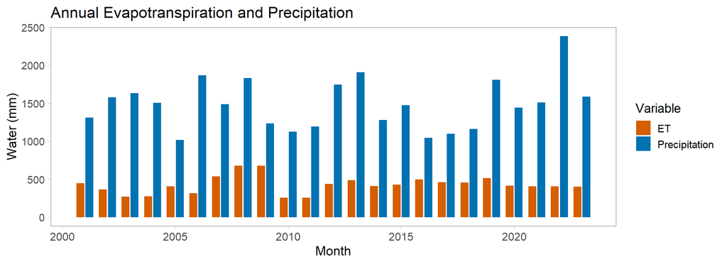

```r
# Constants
rho_w <- 1000         # kg/m3 density of water
lambda <- 2.26e6       # J/kg latent heat of vaporization
seconds_per_day <- 86400

# Calculate ET in mm/day from LE_F_MDS
df.DD <- df.DD %>%
  mutate(
    ET_mm_day = (LE_F_MDS * seconds_per_day) / (rho_w * lambda) *1000 #convert from m to mm of water
  )

# Summarize total ET and P per year (Growing season only)
annual_summary <- df.DD %>%
  filter(month %in% 5:10) %>%  # Growing season (May to October in N hemisphere). If working on Br-Sa1, change to
  group_by(year) %>%
  summarise(
    total_ET_mm = sum(ET_mm_day, na.rm = TRUE),
    total_precip_mm = sum(P_F, na.rm = TRUE),
    n_days = sum(!is.na(ET_mm_day)),
    .groups = "drop") %>%
  mutate(ET_over_P =  total_ET_mm / total_precip_mm)

#if working on Br-Sa1, use this code
#annual_summary <- df.DD %>%
  #filter(month %in% c(9:12, 1:5)) %>%
  #mutate(year = if_else(month >= 9, year + 1, year)) %>%  # assign Sept–Dec to next year
  #group_by(year) %>%
  #summarise(
    #total_ET_mm = sum(ET_mm_day, na.rm = TRUE),
    #total_precip_mm = sum(P_F, na.rm = TRUE),
    #n_days = sum(!is.na(ET_mm_day)),
    #.groups = "drop"
 #) %>%
  #mutate(ET_over_P = if_else(total_precip_mm > 0, total_ET_mm / total_precip_mm, NA_real_))


annual_long <- annual_summary %>%
  select(year, total_ET_mm, total_precip_mm) %>%
    pivot_longer(cols = c(total_ET_mm, total_precip_mm),
               names_to = "variable",
               values_to = "value")

### plot the annual trend
ggplot(annual_long, aes(x = year, y = value, fill = variable)) +
  geom_bar(stat = "identity", position = position_dodge(width = 0.8), width = 0.7) +
  scale_fill_manual(values = c("total_ET_mm" = "#D55E00", "total_precip_mm" ="#0072B2" ),
                    labels = c("ET", "Precipitation")) +
  labs(x = "Month", y = "Water (mm)", fill = "Variable",
       title = "Annual Evapotranspiration and Precipitation") +
  my_theme
```

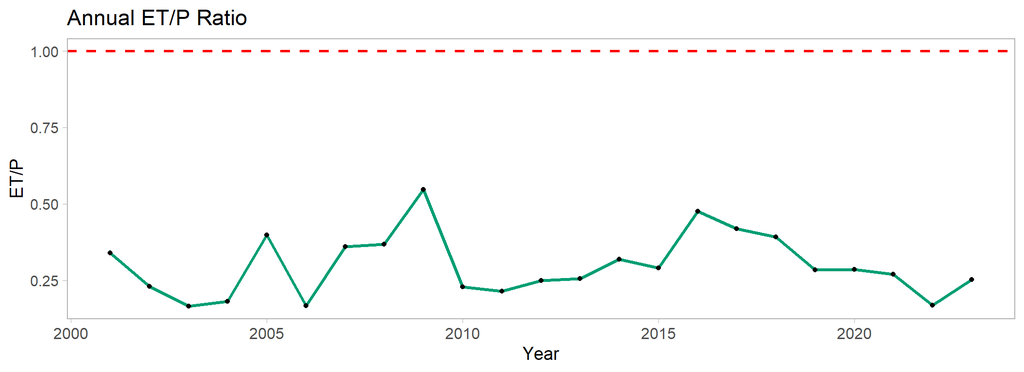

```r
### plot annual ET/P trend
ggplot(annual_summary, aes(x = year, y = ET_over_P)) +
  geom_line(color = "#009E73", size = 1.2) +
  geom_point(color = "black") +
  geom_hline(yintercept = 1, color = "red", linetype = "dashed", size = 1) +
  labs(title = "Annual ET/P Ratio",
       x = "Year",
       y = "ET/P") +
  my_theme
```

Where to go from here: - Interpret the figure and include it in your group presentation.

## Task 3: Energy balance closure

The **energy balance closure equation** is used to evaluate how well the measured energy components at an eddy covariance site balance. The standard form is:

$$R_n - G = H + LE$$

Where:

- $R_n$: Net radiation *(W m⁻²)*
- $G$: Ground heat flux *(W m⁻²)*
- $H$: Sensible heat flux *(W m⁻²)*
- $LE$: Latent heat flux *(W m⁻²)*

A commonly used metric is the **closure ratio**, defined as:

$$\text{Closure Ratio} = \frac{H + LE}{R_n - G}$$

This ratio should ideally be close to **1**.  
Values significantly below 1 suggest underestimation of turbulent fluxes ($H + LE$), possibly due to:

- Measurement errors
- Missing energy storage terms
- Unaccounted biophysical or soil processes

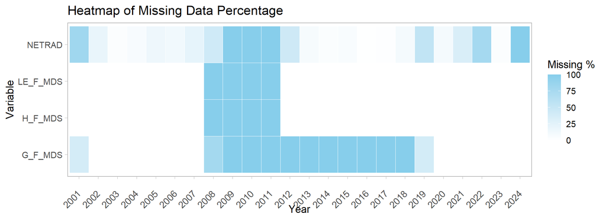

```r
xlab  = expression(Rn+G~'('*W~m^{-2}*')')
ylab = expression(H+LE~'('*W~m^{-2}*')')

# check if there are NAs in NETRAD, G, H and LE
{
  # Calculate missing percentage by year
  na_pct <- df.HH %>%
    group_by(year) %>%
    summarise(
      NETRAD = mean(is.na(NETRAD)) * 100,
      G_F_MDS = mean(is.na(G_F_MDS)) * 100,
      H_F_MDS = mean(is.na(H_F_MDS)) * 100,
      LE_F_MDS = mean(is.na(LE_F_MDS)) * 100
    ) %>%
    pivot_longer(cols = -year, names_to = "variable", values_to = "na_percent")

  # Plot heatmap
  ggplot(na_pct, aes(x = factor(year), y = variable, fill = na_percent)) +
    geom_tile(color = "white") +
    scale_fill_gradient(low = "white", high = "skyblue", name = "Missing %") +
    labs(x = "Year", y = "Variable", title = "Heatmap of Missing Data Percentage") +
    my_theme +
    theme(axis.text.x = element_text(angle = 45, vjust = 0.5, hjust = 1))
}
```

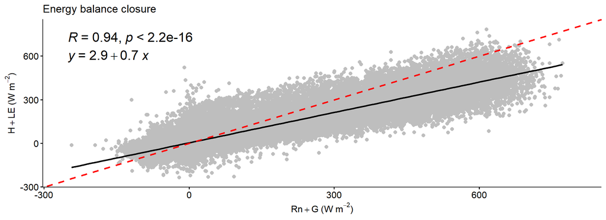

```r
# data frame for plotting
df.plot = data.frame(v1 = df.HH$NETRAD - df.HH$G_F_MDS,
                v2 = df.HH$H_F_MDS + df.HH$LE_F_MDS,
                year = df.HH$year)

ggscatter(
  data = df.plot,
  x = "v1",  y = "v2",
  color = "grey",
  add = "reg.line",
  add.params = list(color = "black", size = 1),  # regression line
  conf.int = TRUE, cor.coef = TRUE,
  cor.coeff.args = list(size = 6),
  title = "Energy balance closure"
) +
stat_regline_equation(
  aes(label = ..eq.label..),
  label.x = -250, label.y = 600, # adjust the position if needed
  size = 6
) +
  geom_abline(slope = 1, intercept = 0, color = "red", linetype = "dashed", size = 1) +
  xlab(xlab) + ylab(ylab) +
  xlim(-250, 800) + ylim(-250,800) # adjust the limits if needed
```

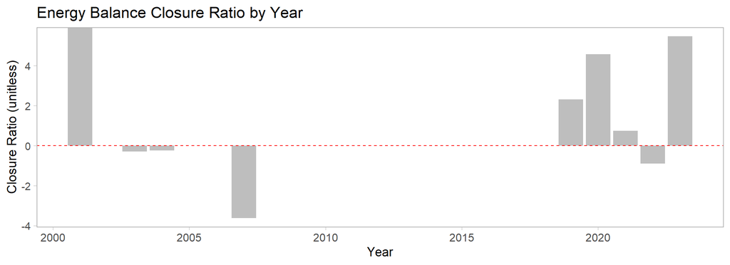

```r
# Calculate closure ratio for each year
df.summary <- df.plot %>%
  filter(!is.na(v1), !is.na(v2)) %>%
  mutate(closure_ratio = v2 / v1) %>%
  group_by(year) %>%
  summarise(mean_closure = mean(closure_ratio, na.rm = TRUE))

ggplot(df.summary, aes(x = year, y = mean_closure)) +
  geom_col(fill = "grey") +
  geom_hline(yintercept = 0, linetype = "dashed", color = "red") +
  labs(
    title = "Energy Balance Closure Ratio by Year",
    x = "Year", y = "Closure Ratio (unitless)"
  ) + my_theme
```

Where to go from here:

- Interpret the figures and include them in your group presentation.

# References

- Pastorello, Gilberto, et al. “The FLUXNET2015 dataset and the ONEFlux processing pipeline for eddy covariance data.” Scientific data 7.1 (2020): 225.